# Day Fourteen: R Markdown

Lindsay Poirier

# Lorem ipsum

Lorem ipsum dolor sit amet, consectetur adipiscing elit, sed do eiusmod tempor incididunt ut **labore et dolore** magna aliqua. Fusce ut placerat orci nulla pellentesque dignissim enim sit. Eu volutpat odio facilisis mauris sit amet massa vitae tortor. In nisl nisi scelerisque eu ultrices vitae auctor eu augue. Adipiscing commodo elit at imperdiet dui accumsan.

## Aenean sed adipiscing

Aenean sed *adipiscing diam donec* adipiscing tristique risus. Massa ultricies mi quis hendrerit dolor magna eget est. Dolor sed viverra ipsum nunc aliquet bibendum.<sup>1</sup>

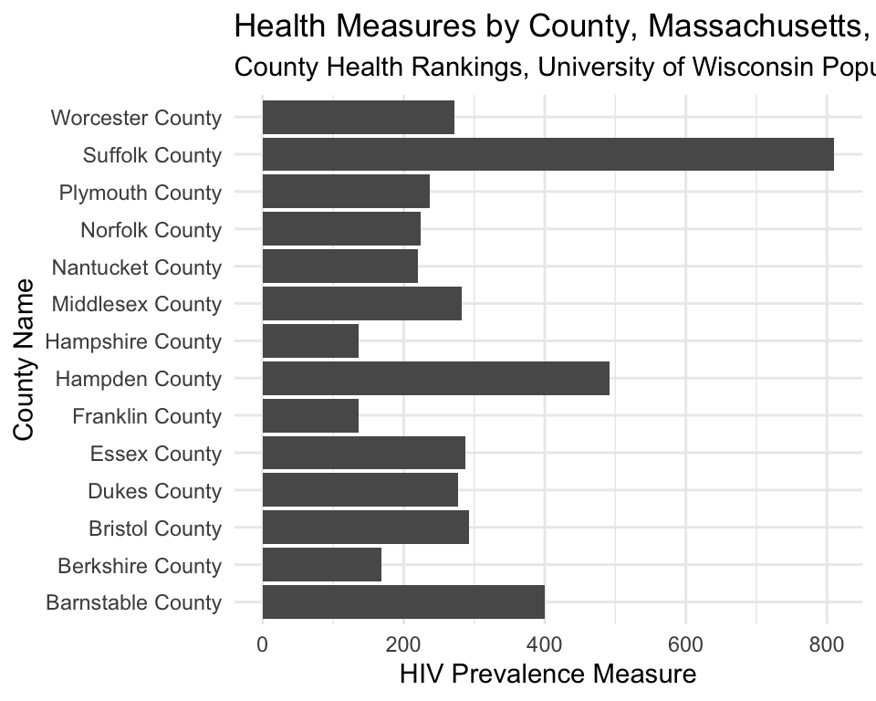

```r
ggplot(ma_county_health_2021,
       aes(x = Name, y = HIV_prevalence_raw_value)) +
  geom_col() +
  coord_flip() +
  labs(title = "Health Measures by County, Massachusetts, 2021",
       x = "County Name",
       y = "HIV Prevalence Measure",
       subtitle = "County Health Rankings, University of Wisconsin Population Health Institute") +
  theme_minimal()
```

<sup>1</sup> Data at [County Health Rankings](https://www.countyhealthrankings.org/)

# Vulputate

Vulputate eu scelerisque felis imperdiet proin:

- Molestie a iaculis at erat pellentesque adipiscing commodo.
- Ultrices sagittis orci a scelerisque purus semper eget duis at.
- Sed nisi lacus sed viverra.

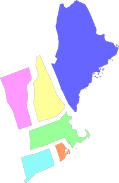

Libero nunc consequat interdum varius sit amet mattis vulputate. Orci sagittis eu volutpat odio facilisis mauris.

> Aliquet sagittis id consectetur purus ut. Arcu non odio euismod lacinia at quis risus sed. Vel elit scelerisque mauris pellentesque pulvinar pellentesque habitant morbi tristique. Penatibus et magnis dis parturient montes.

## Viverra ipsum

Viverra ipsum nunc aliquet bibendum enim. Non enim praesent elementum facilisis leo vel fringilla est. Orci dapibus ultrices in iaculis nunc sed augue lacus. Quisque non tellus orci ac auctor augue. Pulvinar sapien et ligula ullamcorper malesuada. Amet mauris commodo quis imperdiet.

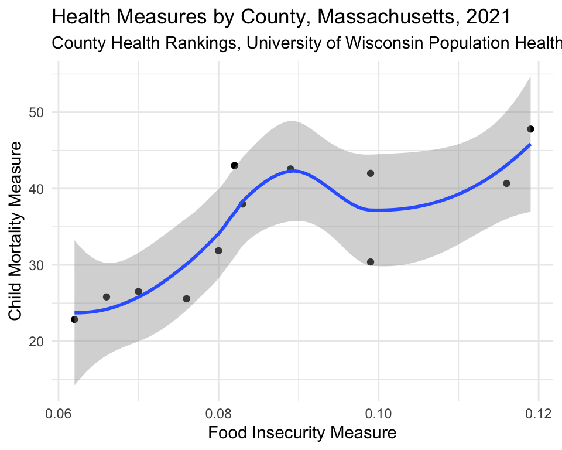

```r
# Don't show messages in final document
# Don't show warnings in final document
ggplot(ma_county_health_2021,
       aes(x = Food_insecurity_raw_value, y = Child_mortality_raw_value)) +
  geom_point() +
  labs(title = "Health Measures by County, Massachusetts, 2021",
       x = "Food Insecurity Measure",
       y = "Child Mortality Measure",
       subtitle = "County Health Rankings, University of Wisconsin Population Health Institute") +
  theme_minimal() +
  geom_smooth()
```

Eu scelerisque felis imperdiet proin fermentum leo vel orci. Laoreet id donec ultrices tincidunt arcu.